# Hyne Tumbarumba Trial: Green Board Data

# Board Dimensions

Let’s compare the dimension data in the trimmer (f=FlitchDetail, b=BoardDetail), SICK (s=skimage.regionprops), ecoustic (e)YY

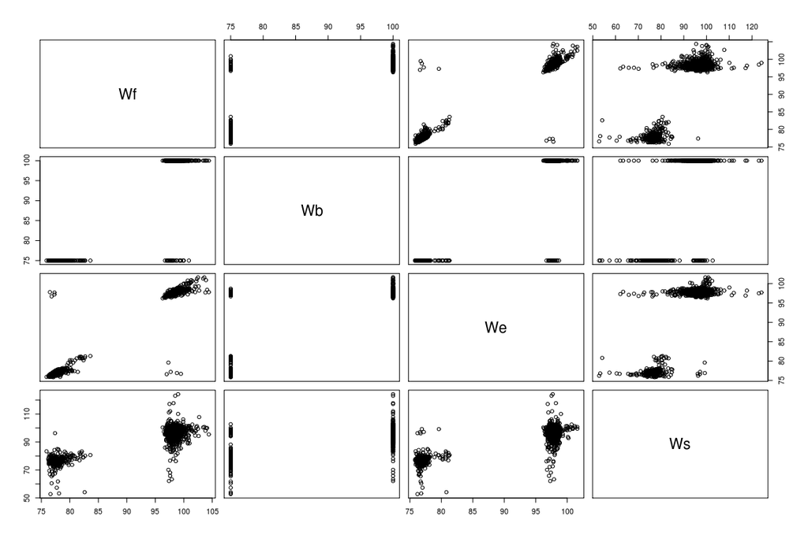

```r
pairs(B[,c('Wf','Wb','We','Ws')])
```

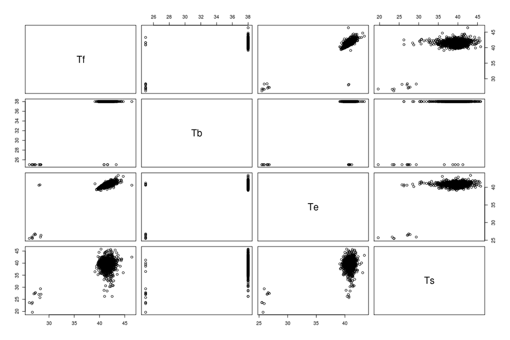

```r
pairs(B[,c('Tf','Tb','Te','Ts')])
```

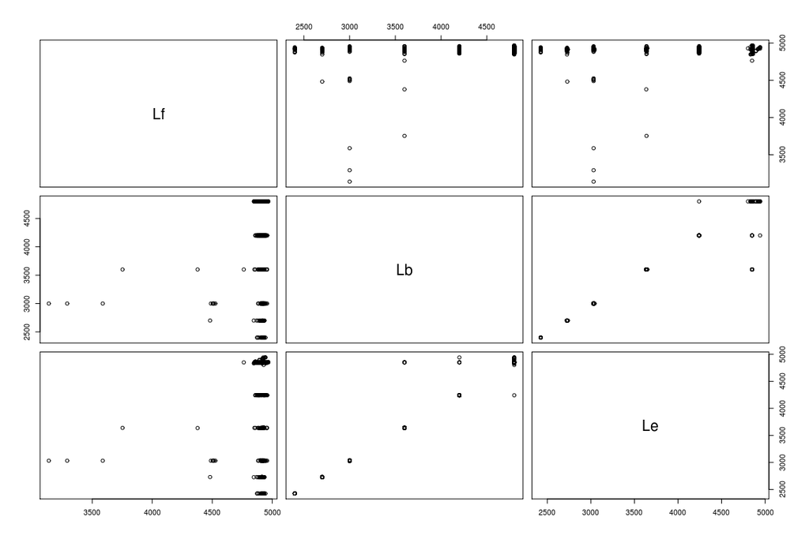

```r
pairs(B[,c('Lf','Lb','Le')])
```

```r
imismatch = abs(B$Wf-B$We)>10 | abs(B$Tf-B$Te)>10 | abs(B$Lb-B$Le)>200
B[imismatch,c('flitchId','isByproduct','Wf','Wb','Ws','We','Tf','Tb','Ts','Te','Lf','Lb','Le')]
```

```
##      flitchId isByproduct   Wf Wb        Ws   We   Tf Tb       Ts   Te
## 248   1281309           1 97.5 75  85.22223 98.4 41.3 38 38.03878 40.7
## 358   1281419           1 99.9 75  97.13408 97.6 41.3 38 37.40770 41.4
## 365   1281426           1 97.3 75  98.30507 97.1 28.0 25 27.00420 40.6
## 500   1281561           1 97.0 75  97.03825 76.6 42.7 38 39.17180 40.6
## 516   1281577           1 97.3 75  99.20158 79.6 40.7 38 38.08673 40.4
## 675   1281736           1 97.3 75  98.52973 97.0 42.4 38 43.27950 41.1
## 692   1281753           1 98.0 75  94.38307 97.8 41.6 38 38.11322 41.0
## 736   1281797           1 97.2 75 100.23004 97.2 41.2 38 44.60452 41.2
## 823   1281884           1 99.5 75  96.10237 76.7 41.3 38 40.43689 41.3
## 867   1281928           1 98.1 75  94.55882 97.2 41.8 38 41.80085 40.7
## 1074  1282135           1 98.0 75  94.37286 97.6 41.3 38 37.84145 40.5
## 1112  1282173           1 98.0 75  94.16214 98.4 42.0 38 36.56078 40.9
## 1194  1282255           1 77.3 75  72.17913 97.2 40.9 25 36.52155 40.8
## 1389  1282450           1 77.3 75  72.59385 97.7 43.3 25 40.04053 40.9
```

[output cut: 27 more lines]

The 19 boards (5 of them 100x40s) with significantly different dimensions in the FlitchDetail and Ecoustic tables are all byproducts that normally would have been tippled out and resawn. Instead they were passed through the trim saw and on to the ecoustic which, since it is triggered locally with a PE, tapped them. If the PLC dosn’t know about these boards then the ecoustic acquires the dimensions of the previous board from the PLC. In these cases, the FlitchDetail estimates of dimensions are more likely best, and Density and MOE should be recalculated (but using the BoardDetail length!). In fact, Density and MOE could be recalculated for all `isByproduct=1` boards. To do this requires estimating volume from FlitchDetail nominal dimensions (rather than the 3D cloud that the USNR software would have used) and extracting resonant frequency from ecoustic MOE.

AAAARGGGH. Some 100x40’s that the optimiser thought should be re-edged were also trimmed (probably because the do-not-trim logic was based on optimised rather than actual board dimensions) e.g. FlitchId 1282173.

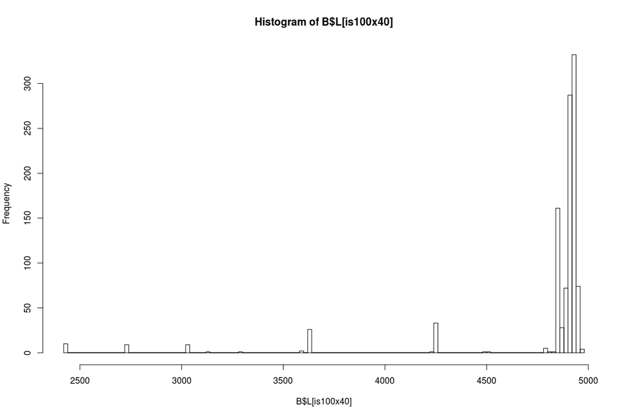

```r
hist(B$L[is100x40],100)
```

Is log length distinct enough to help identify boards that no good barcode read was extracted from?

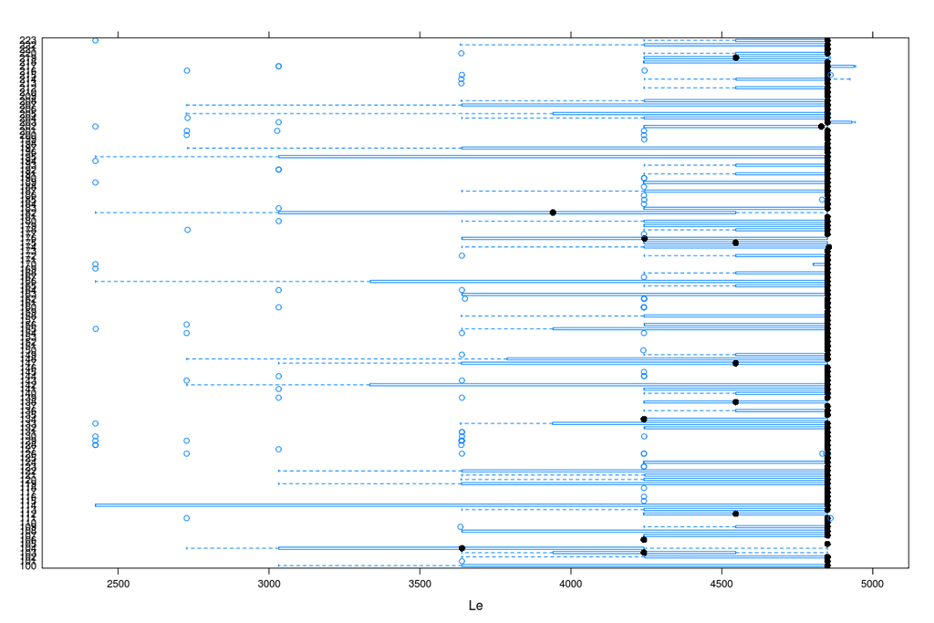

```r
bwplot(as.factor(SWILogNumber) ~ Le, B, subset=is100x40)
```

## Board Orientation in SICK Images

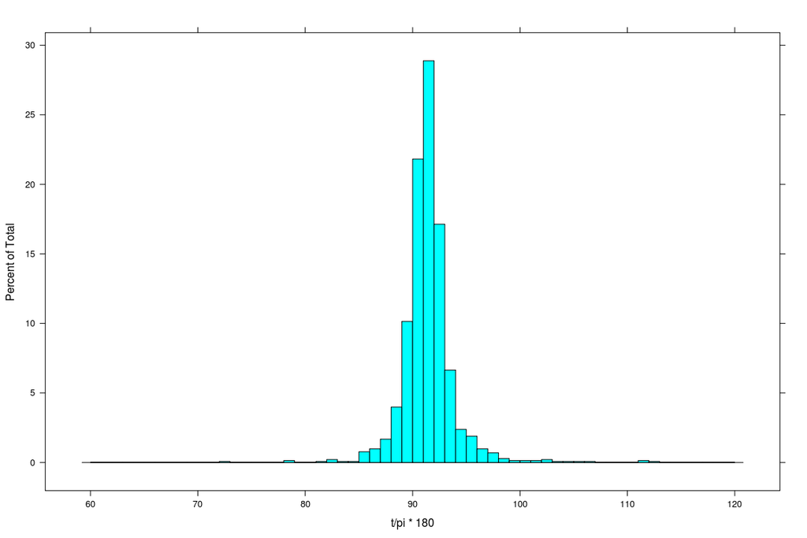

```r
ii = !is.na(B$theta_s)
t = B$theta_s[ii]
t[t<0] = pi + t[t<0]
histogram(t/pi*180., breaks=seq(60,120))
```

```r
summary(t*180/pi)
```

```
##    Min. 1st Qu.  Median    Mean 3rd Qu.    Max.
##   72.06   90.40   91.31   91.41   92.23  112.30
```

Based on:

1. sequence
2. untrimmed (FlitchDetail) length
3. time (but apart from limited cases where whole chain flushed no more info than sequence and a lot harder to work with)
4. Saw pattern (see below) but this is pretty tricky

Not much than can be done about the boards 73 boards that passed through while the SICK camera was off (from logs: 161, 110, 159, 101, 184, 178, 120, 122, 116, 118, 106, 102, 175, 121, 183, 129)

```r
plot(1:nrow(B.all), B.all$Lf, cex=0.1)#, xlim=c(0,30))
text(c(1:nrow(B.all)), B.all$Lf+40, B.all$SWILogNumber, cex=0.7)
```

[figure not shown]

```r
# Do this using plot.ly (so zoom-pan-identify works easily):

py <- plotly()
trace0 <- list(
  #x = B.all$t.trimmer2,
  x = 1:nrow(B.all),
  y = B.all$Lf,
  mode = "markers+text",
  text = B.all$SWILogNumber,
  textposition = "top",
  type = "scatter"
   )
layout <- list(
  #xaxis = list(range = c(1, 15)),
  xaxis = list(range = c(1480, 1580)),
  #yaxis = list(range = c(4600, 5000))
  yaxis = list(range = c(4850, 4980))
)
response <- py$plotly(trace0, kwargs=list(layout=layout, filename="hyne-untrimmed-board-length", fileopt="overwrite"))
response$url
```

```
## [1] "https://plot.ly/~letme1n/1"
```

## Board Density, MOE and SWV

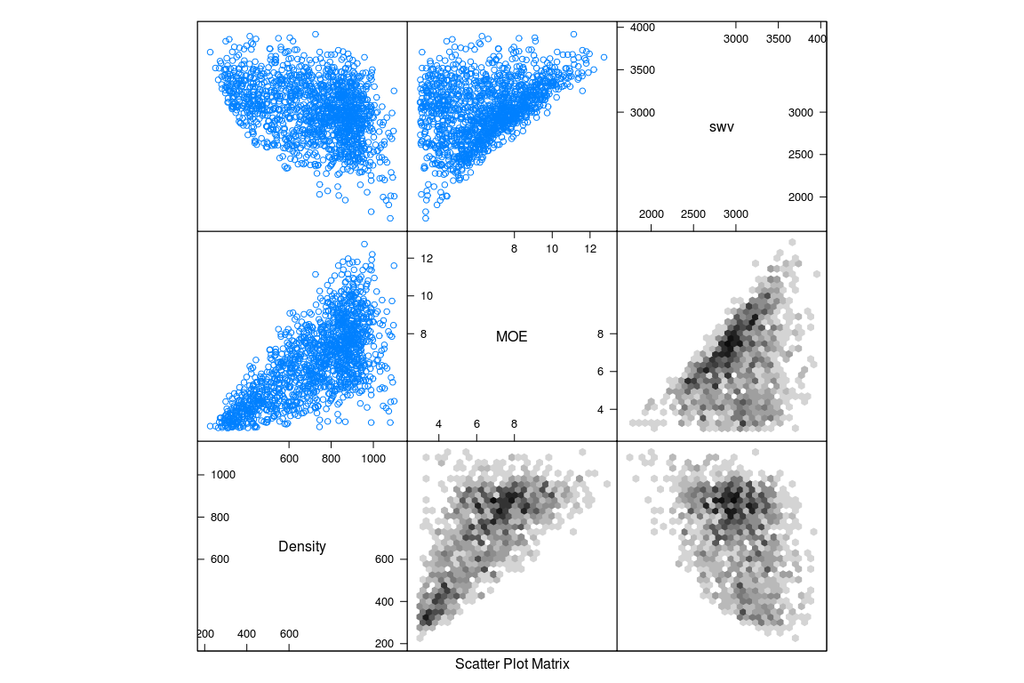

```r
splom(B[,c('Density','MOE','swv')], lower.panel=function(x,y,...){panel.hexbinplot(x,y)})
```

Hmmm. What green board data have we got to compare this with?

```r
L = merge(L, ddply(B, .(SWILogNumber), summarize,
                   nboards=length(SWILogNumber),
                   boardVolume=sum(V),
                   boardArea=sum(W*T),
                   avgBoardMOE = sum(MOE*W*T)/boardArea,
                   avgBoardDEN = sum(Density*W*T)/boardArea,
                   avgBoardSWV = sum(swv*W*T)/boardArea),
          by="SWILogNumber")
L = merge(L,
          ddply(B, .(SWILogNumber), .fun=function (all.boards) {
            c=subset(all.boards,substr(all.boards$parent,1,4)=='cant')
            if (nrow(c)<1) {
              swv = NA
            } else {
              swv = sum(c$swv*c$W*c$T)/sum(c$W*c$T)
            }
            return (data.frame(SWILogNumber=all.boards$SWILogNumber[1], nCantBoards=nrow(c), avgCantBoardSWV=swv))
            }),
          by="SWILogNumber")
L$recFrac = L$boardVolume/L$volume
L$den = L$weight/L$volume
L$MOE = L$SWV^2*L$den / 1e9
L$log.swv = L$SWV # use hitman velocity rather than calibre as there are fewer NA's
```

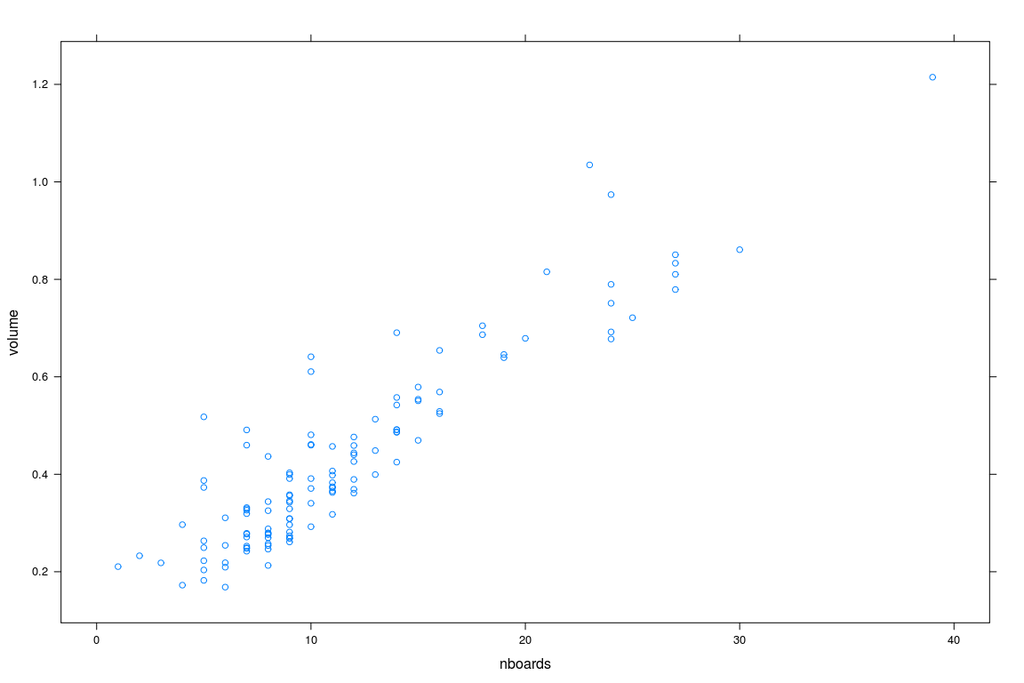

```r
xyplot(volume ~ nboards, L)
```

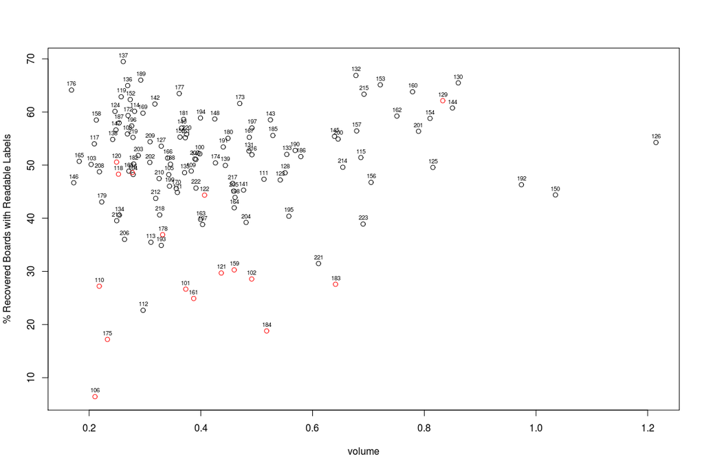

```r
suspect.lognumbers= c(161, 110, 159, 101, 184, 178, 120, 122, 116, 118, 106, 102, 175, 121, 183, 129) # logs likely to have boards the SIC camera missed during outage
clr = rep('black',nrow(L))
clr[L$SWILogNumber %in% suspect.lognumbers] = 'red'
plot(boardVolume/volume*100 ~ volume, L, ylab='% Recovered Boards with Readable Labels', col=clr)
text(L$volume, L$boardVolume/L$volume*100+1.2, L$SWILogNumber, cex=0.6)
```

Why is log 137 the best recovered? All boards from 137 are actual reads from the SICK camera rather than maual assignations.

## Average Board Density

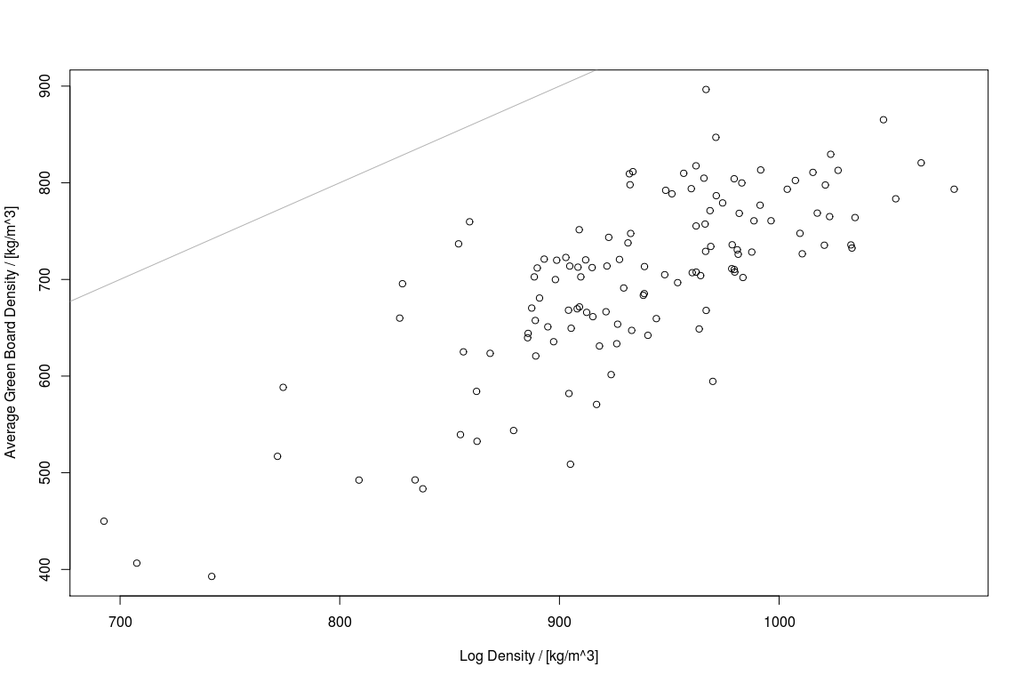

```r
plot(avgBoardDEN ~ den, L, xlab='Log Density / [kg/m^3]', ylab='Average Green Board Density / [kg/m^3]')
abline(c(0,1),col='grey70')
```

```r
summary(m <- lm(avgBoardDEN ~ den + heartVolFrac, L))
```

```
##
## Call:
## lm(formula = avgBoardDEN ~ den + heartVolFrac, data = L)
##
## Residuals:
##      Min       1Q   Median       3Q      Max
## -160.374  -37.777   -4.736   40.981  159.981
##
## Coefficients:
##               Estimate Std. Error t value Pr(>|t|)
## (Intercept)  -201.4134   163.5470  -1.232    0.221
## den             0.9823     0.1523   6.449 2.46e-09 ***
## heartVolFrac  -68.8044   107.1280  -0.642    0.522
## ---
## Signif. codes:  0 '***' 0.001 '**' 0.01 '*' 0.05 '.' 0.1 ' ' 1
##
## Residual standard error: 60.13 on 120 degrees of freedom
## Multiple R-squared:  0.5956, Adjusted R-squared:  0.5889
## F-statistic: 88.38 on 2 and 120 DF,  p-value: < 2.2e-16
```

Why is log density so much higher than average board density? Just due to over representation of inner material?

## Average Board SWV

Only look at hitman SWV due to issues with calibre SWV (see `hyne-log.Rmd`).

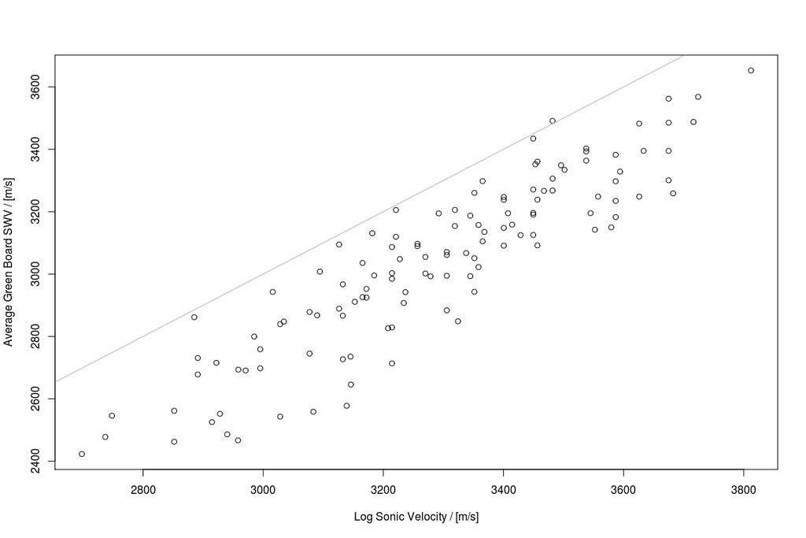

```r
plot(avgBoardSWV ~ SWV, L, xlab='Log Sonic Velocity / [m/s]', ylab='Average Green Board SWV / [m/s]')
abline(c(0,1),col='grey70')
```

```r
summary(m <- lm(avgBoardSWV ~ SWV, L))
```

```
##
## Call:
## lm(formula = avgBoardSWV ~ SWV, data = L)
##
## Residuals:
##     Min      1Q  Median      3Q     Max
## -306.63  -74.07   12.99   75.57  249.26
##
## Coefficients:
##               Estimate Std. Error t value Pr(>|t|)
## (Intercept) -392.26040  148.63533  -2.639  0.00942 **
## SWV            1.04378    0.04508  23.155  < 2e-16 ***
## ---
## Signif. codes:  0 '***' 0.001 '**' 0.01 '*' 0.05 '.' 0.1 ' ' 1
##
## Residual standard error: 119.6 on 120 degrees of freedom
##   (1 observation deleted due to missingness)
## Multiple R-squared:  0.8171, Adjusted R-squared:  0.8156
## F-statistic: 536.1 on 1 and 120 DF,  p-value: < 2.2e-16
```

```r
summary(m <- lm(avgBoardSWV ~ SWV + heartVolFrac, L))
```

```
##
## Call:
## lm(formula = avgBoardSWV ~ SWV + heartVolFrac, data = L)
##
## Residuals:
##     Min      1Q  Median      3Q     Max
## -304.71  -72.88   13.72   76.04  248.86
##
## Coefficients:
##                Estimate Std. Error t value Pr(>|t|)
## (Intercept)  -388.17938  151.84409  -2.556   0.0118 *
## SWV             1.04133    0.04829  21.565   <2e-16 ***
## heartVolFrac   17.54688  120.27446   0.146   0.8843
## ---
## Signif. codes:  0 '***' 0.001 '**' 0.01 '*' 0.05 '.' 0.1 ' ' 1
##
## Residual standard error: 120.1 on 119 degrees of freedom
##   (1 observation deleted due to missingness)
## Multiple R-squared:  0.8171, Adjusted R-squared:  0.8141
## F-statistic: 265.9 on 2 and 119 DF,  p-value: < 2.2e-16
```

```r
summary(m <- lm(avgBoardSWV ~ SWV + heartVolFrac + den, L))
```

```
##
## Call:
## lm(formula = avgBoardSWV ~ SWV + heartVolFrac + den, data = L)
##
## Residuals:
##     Min      1Q  Median      3Q     Max
## -274.00  -72.95   14.52   70.65  242.59
##
## Coefficients:
##                Estimate Std. Error t value Pr(>|t|)
## (Intercept)   387.82163  345.06958   1.124   0.2633
## SWV             1.04876    0.04736  22.145   <2e-16 ***
## heartVolFrac -435.70662  216.67045  -2.011   0.0466 *
## den            -0.74647    0.29957  -2.492   0.0141 *
## ---
## Signif. codes:  0 '***' 0.001 '**' 0.01 '*' 0.05 '.' 0.1 ' ' 1
##
## Residual standard error: 117.6 on 118 degrees of freedom
##   (1 observation deleted due to missingness)
## Multiple R-squared:  0.8263, Adjusted R-squared:  0.8219
## F-statistic: 187.1 on 3 and 118 DF,  p-value: < 2.2e-16
```

```r
summary(m <- lm(avgBoardSWV ~ SWV + heartVolFrac + avgBoardDEN, L))
```

```
##
## Call:
## lm(formula = avgBoardSWV ~ SWV + heartVolFrac + avgBoardDEN,
##     data = L)
##
## Residuals:
##     Min      1Q  Median      3Q     Max
## -308.86  -71.48   12.03   77.90  216.47
##
## Coefficients:
##                Estimate Std. Error t value Pr(>|t|)
## (Intercept)   350.29967  225.38719   1.554   0.1228
## SWV             0.98172    0.04735  20.732  < 2e-16 ***
## heartVolFrac -359.06919  143.64033  -2.500   0.0138 *
## avgBoardDEN    -0.65188    0.15441  -4.222 4.79e-05 ***
## ---
## Signif. codes:  0 '***' 0.001 '**' 0.01 '*' 0.05 '.' 0.1 ' ' 1
##
## Residual standard error: 112.4 on 118 degrees of freedom
##   (1 observation deleted due to missingness)
## Multiple R-squared:  0.8411, Adjusted R-squared:  0.8371
## F-statistic: 208.3 on 3 and 118 DF,  p-value: < 2.2e-16
```

## Average Board MOE

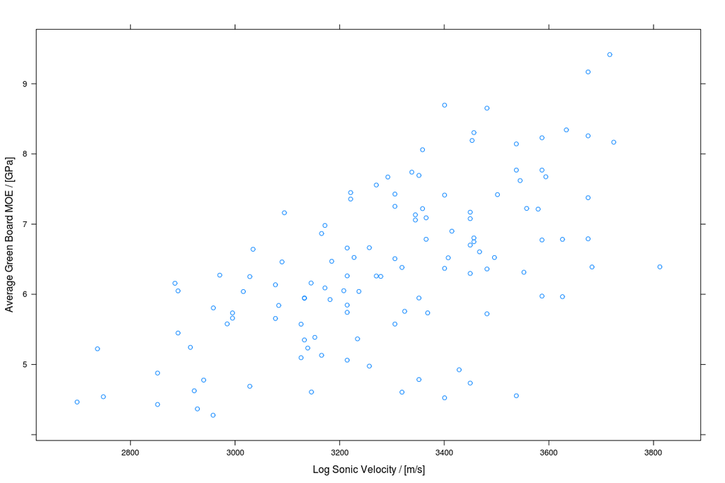

```r
xyplot(avgBoardMOE ~ SWV, L, xlab='Log Sonic Velocity / [m/s]', ylab='Average Green Board MOE / [GPa]')
```

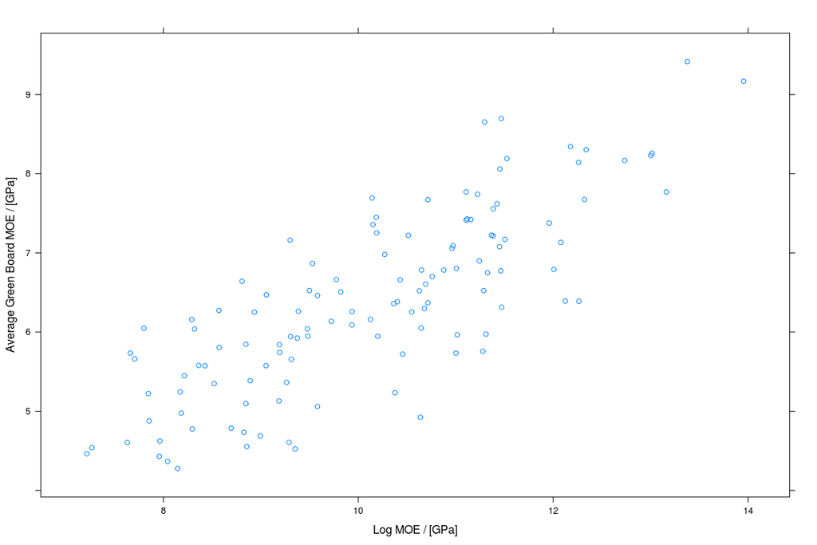

```r
xyplot(avgBoardMOE ~ MOE, L, xlab='Log MOE / [GPa]', ylab='Average Green Board MOE / [GPa]')
```

```r
summary(m <- lm(avgBoardMOE ~ MOE, L))
```

```
##
## Call:
## lm(formula = avgBoardMOE ~ MOE, data = L)
##
## Residuals:
##      Min       1Q   Median       3Q      Max
## -1.76947 -0.42905 -0.02078  0.44396  1.55460
##
## Coefficients:
##             Estimate Std. Error t value Pr(>|t|)
## (Intercept)  0.17282    0.42926   0.403    0.688
## MOE          0.61299    0.04193  14.618   <2e-16 ***
## ---
## Signif. codes:  0 '***' 0.001 '**' 0.01 '*' 0.05 '.' 0.1 ' ' 1
##
## Residual standard error: 0.6838 on 120 degrees of freedom
##   (1 observation deleted due to missingness)
## Multiple R-squared:  0.6404, Adjusted R-squared:  0.6374
## F-statistic: 213.7 on 1 and 120 DF,  p-value: < 2.2e-16
```

```r
summary(m <- lm(avgBoardMOE ~ SWV, L))
```

```
##
## Call:
## lm(formula = avgBoardMOE ~ SWV, data = L)
##
## Residuals:
##      Min       1Q   Median       3Q      Max
## -2.54062 -0.60211  0.02656  0.60749  1.99237
##
## Coefficients:
##               Estimate Std. Error t value Pr(>|t|)
## (Intercept) -3.0188520  1.1257598  -2.682  0.00836 **
## SWV          0.0028588  0.0003414   8.373 1.21e-13 ***
## ---
## Signif. codes:  0 '***' 0.001 '**' 0.01 '*' 0.05 '.' 0.1 ' ' 1
##
## Residual standard error: 0.906 on 120 degrees of freedom
##   (1 observation deleted due to missingness)
## Multiple R-squared:  0.3688, Adjusted R-squared:  0.3635
## F-statistic: 70.11 on 1 and 120 DF,  p-value: 1.211e-13
```

```r
summary(m <- lm(avgBoardMOE ~ MOE + den, L))
```

```
##
## Call:
## lm(formula = avgBoardMOE ~ MOE + den, data = L)
##
## Residuals:
##      Min       1Q   Median       3Q      Max
## -1.67513 -0.38362  0.01993  0.39976  1.59725
##
## Coefficients:
##               Estimate Std. Error t value Pr(>|t|)
## (Intercept) -2.0208268  0.8556733  -2.362  0.01982 *
## MOE          0.5820680  0.0420087  13.856  < 2e-16 ***
## den          0.0026832  0.0009144   2.934  0.00401 **
## ---
## Signif. codes:  0 '***' 0.001 '**' 0.01 '*' 0.05 '.' 0.1 ' ' 1
##
## Residual standard error: 0.6631 on 119 degrees of freedom
##   (1 observation deleted due to missingness)
## Multiple R-squared:  0.6646, Adjusted R-squared:  0.659
## F-statistic: 117.9 on 2 and 119 DF,  p-value: < 2.2e-16
```

```r
summary(m <- lm(avgBoardMOE ~ SWV + den, L))
```

```
##
## Call:
## lm(formula = avgBoardMOE ~ SWV + den, data = L)
##
## Residuals:
##      Min       1Q   Median       3Q      Max
## -1.71016 -0.42687  0.02635  0.44095  1.60672
##
## Coefficients:
##               Estimate Std. Error t value Pr(>|t|)
## (Intercept) -1.388e+01  1.388e+00  -10.00   <2e-16 ***
## SWV          3.548e-03  2.642e-04   13.43   <2e-16 ***
## den          9.198e-03  9.357e-04    9.83   <2e-16 ***
## ---
## Signif. codes:  0 '***' 0.001 '**' 0.01 '*' 0.05 '.' 0.1 ' ' 1
##
## Residual standard error: 0.6758 on 119 degrees of freedom
##   (1 observation deleted due to missingness)
## Multiple R-squared:  0.6516, Adjusted R-squared:  0.6458
## F-statistic: 111.3 on 2 and 119 DF,  p-value: < 2.2e-16
```

```r
summary(m <- lm(avgBoardMOE ~ MOE + heartVolFrac, L))
```

```
##
## Call:
## lm(formula = avgBoardMOE ~ MOE + heartVolFrac, data = L)
##
## Residuals:
##     Min      1Q  Median      3Q     Max
## -1.6921 -0.4324 -0.0388  0.4639  1.5095
##
## Coefficients:
##              Estimate Std. Error t value Pr(>|t|)
## (Intercept)   0.69008    0.45383   1.521  0.13102
## MOE           0.60237    0.04088  14.734  < 2e-16 ***
## heartVolFrac -1.80243    0.62579  -2.880  0.00471 **
## ---
## Signif. codes:  0 '***' 0.001 '**' 0.01 '*' 0.05 '.' 0.1 ' ' 1
##
## Residual standard error: 0.6639 on 119 degrees of freedom
##   (1 observation deleted due to missingness)
## Multiple R-squared:  0.6638, Adjusted R-squared:  0.6582
## F-statistic: 117.5 on 2 and 119 DF,  p-value: < 2.2e-16
```

```r
summary(m <- lm(avgBoardMOE ~ SWV + heartVolFrac, L))
```

```
##
## Call:
## lm(formula = avgBoardMOE ~ SWV + heartVolFrac, data = L)
##
## Residuals:
##      Min       1Q   Median       3Q      Max
## -1.73952 -0.46534 -0.09091  0.61570  1.56269
##
## Coefficients:
##                Estimate Std. Error t value Pr(>|t|)
## (Intercept)  -4.3726163  0.9322522  -4.690 7.34e-06 ***
## SWV           0.0036727  0.0002965  12.388  < 2e-16 ***
## heartVolFrac -5.8206963  0.7384294  -7.883 1.71e-12 ***
## ---
## Signif. codes:  0 '***' 0.001 '**' 0.01 '*' 0.05 '.' 0.1 ' ' 1
##
## Residual standard error: 0.7374 on 119 degrees of freedom
##   (1 observation deleted due to missingness)
## Multiple R-squared:  0.5853, Adjusted R-squared:  0.5783
## F-statistic: 83.98 on 2 and 119 DF,  p-value: < 2.2e-16
```

```r
summary(m <- lm(avgBoardMOE ~ MOE + heartVolFrac + den, L))
```

```
##
## Call:
## lm(formula = avgBoardMOE ~ MOE + heartVolFrac + den, data = L)
##
## Residuals:
##      Min       1Q   Median       3Q      Max
## -1.67622 -0.39895  0.00185  0.45486  1.55828
##
## Coefficients:
##               Estimate Std. Error t value Pr(>|t|)
## (Intercept)  -0.882597   1.824861  -0.484    0.630
## MOE           0.589509   0.043395  13.585   <2e-16 ***
## heartVolFrac -0.865620   1.225048  -0.707    0.481
## den           0.001595   0.001792   0.890    0.375
## ---
## Signif. codes:  0 '***' 0.001 '**' 0.01 '*' 0.05 '.' 0.1 ' ' 1
##
## Residual standard error: 0.6645 on 118 degrees of freedom
##   (1 observation deleted due to missingness)
## Multiple R-squared:  0.666,  Adjusted R-squared:  0.6576
## F-statistic: 78.45 on 3 and 118 DF,  p-value: < 2.2e-16
```

```r
summary(m <- lm(avgBoardMOE ~ SWV + heartVolFrac + den, L))
```

```
##
## Call:
## lm(formula = avgBoardMOE ~ SWV + heartVolFrac + den, data = L)
##
## Residuals:
##      Min       1Q   Median       3Q      Max
## -1.69782 -0.42456  0.01376  0.48863  1.57085
##
## Coefficients:
##                Estimate Std. Error t value Pr(>|t|)
## (Intercept)  -1.297e+01  1.989e+00  -6.523 1.80e-09 ***
## SWV           3.590e-03  2.729e-04  13.155  < 2e-16 ***
## heartVolFrac -7.978e-01  1.249e+00  -0.639    0.524
## den           8.272e-03  1.726e-03   4.791 4.86e-06 ***
## ---
## Signif. codes:  0 '***' 0.001 '**' 0.01 '*' 0.05 '.' 0.1 ' ' 1
##
## Residual standard error: 0.6775 on 118 degrees of freedom
##   (1 observation deleted due to missingness)
## Multiple R-squared:  0.6528, Adjusted R-squared:  0.644
## F-statistic: 73.97 on 3 and 118 DF,  p-value: < 2.2e-16
```

```r
summary(m <- lm(avgBoardMOE ~ SWV + heartVolFrac + den + avgBoardDEN, L))
```

```
##
## Call:
## lm(formula = avgBoardMOE ~ SWV + heartVolFrac + den + avgBoardDEN,
##     data = L)
##
## Residuals:
##      Min       1Q   Median       3Q      Max
## -1.33707 -0.35998  0.04685  0.41238  1.09554
##
## Coefficients:
##                Estimate Std. Error t value Pr(>|t|)
## (Intercept)  -1.352e+01  1.573e+00  -8.596 4.27e-14 ***
## SWV           4.349e-03  2.335e-04  18.629  < 2e-16 ***
## heartVolFrac -1.106e+00  9.873e-01  -1.120    0.265
## den           6.598e-04  1.633e-03   0.404    0.687
## avgBoardDEN   7.468e-03  8.800e-04   8.486 7.67e-14 ***
## ---
## Signif. codes:  0 '***' 0.001 '**' 0.01 '*' 0.05 '.' 0.1 ' ' 1
##
## Residual standard error: 0.5353 on 117 degrees of freedom
##   (1 observation deleted due to missingness)
## Multiple R-squared:  0.7851, Adjusted R-squared:  0.7778
## F-statistic: 106.9 on 4 and 117 DF,  p-value: < 2.2e-16
```

## Saw Patterns

Plot board centroids:

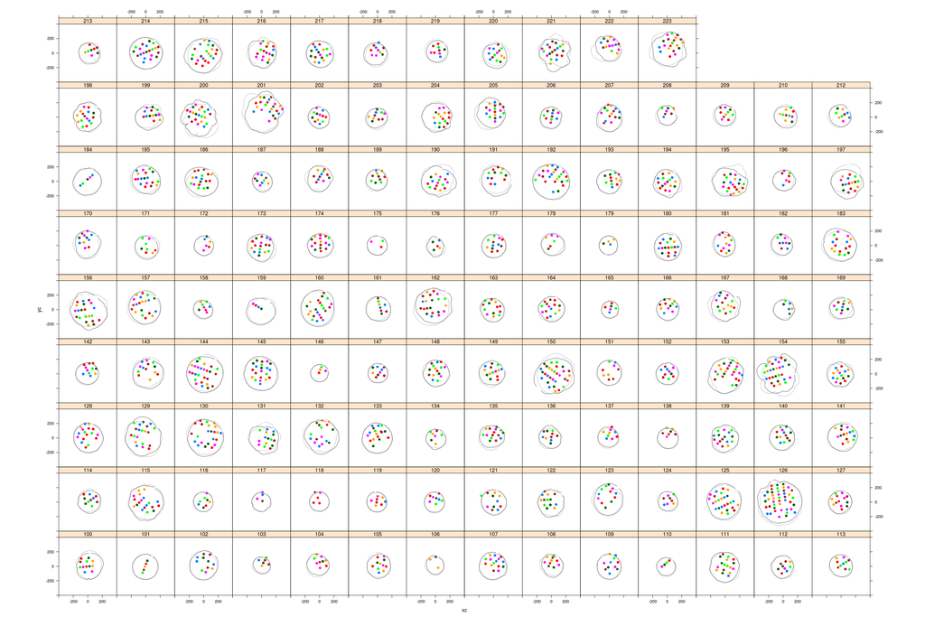

```r
ch = odbcConnect('HYNE','sa','password12')
# get board centroid data - could also do this by pulling xc, yc from TRIMMER2_FlitchDetail
# but doing it this way lets us plot individual barcode information
C = sqlQuery(ch, "select *,
             (i1-42)*0.7071*20.0 - (i2-42)*0.2588*20.0 as x,
(i1-42)*0.7071*20.0 + (i2-42)*0.9659*20.0 as y
             from SICK_barcodes")# where boardCentroidX_mm is not null")
C$xc = C$boardCentroidX_mm
C$yc = C$boardCentroidY_mm
# get digitization data to overlay on board data
D = sqlQuery(ch, "select flipbookNumber, e.digitizationID, type, x_mm as x, y_mm as y from LogEndDigitizations as d, LogEndDigitizationEdges as e, LogEndDigitizationPoints as p
             where p.edgeId=e.id and e.digitizationId=d.id and type='underbark' and logEnd='large'")
D$xrot =  cos(1*pi/4)*D$x + sin(1*pi/4)*D$y
D$yrot = -sin(1*pi/4)*D$x + cos(1*pi/4)*D$y
#
xyplot(yc ~ xc | as.factor(SWILogNumber), C,
       group=imageId,
       aspect='iso', pch=19, type='b',
       xlim=c(-1,1)*400, ylim=c(-1,1)*400) +
  as.layer(xyplot(y ~ x | as.factor(flipbookNumber), D, group=paste(digitizationID, type),
                  type='l',  aspect='iso', col='grey70')) +
  as.layer(xyplot(yrot ~ xrot | as.factor(flipbookNumber), D, group=paste(digitizationID, type),
                  type='l', aspect='iso', col='grey30'))
```